# TidyVerse Vignette: Exploring Global Happiness with dplyr, tidyr, ggplot2 & stringr

Nana Kwasi Danquah

2026-04-12

## Overview

This vignette demonstrates core **TidyVerse** capabilities using the [World Happiness Report dataset](https://www.kaggle.com/datasets/unsdsn/world-happiness) from Kaggle. We’ll explore:

[output not shown]

## 1. Load Packages

```r
library(tidyverse)   # loads dplyr, ggplot2, tidyr, readr, stringr, forcats, purrr
```

## 2. Import Data with `readr`

```r
# Read CSV — readr prints a column specification summary
url <- "https://raw.githubusercontent.com/dsrscientist/dataset1/master/happiness_score_dataset.csv"

# For reproducibility, we embed a small representative dataset inline
# (mirrors the structure of the Kaggle World Happiness Report 2019)
happiness_raw <- tibble::tribble(
  ~Overall.rank, ~Country.or.region,         ~Score, ~GDP.per.capita, ~Social.support, ~Healthy.life.expectancy, ~Freedom.to.make.life.choices, ~Generosity, ~Perceptions.of.corruption,
  1,  "Finland",          7.769, 1.340, 1.587, 0.986, 0.596, 0.153, 0.393,
  2,  "Denmark",          7.600, 1.383, 1.573, 0.996, 0.592, 0.252, 0.410,
  3,  "Norway",           7.554, 1.488, 1.582, 1.028, 0.603, 0.271, 0.341,
  4,  "Iceland",          7.494, 1.380, 1.624, 1.026, 0.591, 0.354, 0.118,
  5,  "Netherlands",      7.488, 1.396, 1.522, 0.999, 0.557, 0.322, 0.298,
  6,  "Switzerland",      7.480, 1.452, 1.526, 1.052, 0.572, 0.263, 0.343,
  7,  "Sweden",           7.343, 1.387, 1.487, 1.009, 0.574, 0.267, 0.373,
  8,  "New Zealand",      7.307, 1.303, 1.557, 1.026, 0.585, 0.330, 0.380,
  9,  "Canada",           7.278, 1.365, 1.505, 1.039, 0.584, 0.285, 0.308,
  10, "Austria",          7.246, 1.376, 1.475, 1.016, 0.532, 0.244, 0.226,
  11, "Australia",        7.228, 1.372, 1.548, 1.036, 0.557, 0.332, 0.290,
  12, "Costa Rica",       7.167, 1.034, 1.441, 0.963, 0.558, 0.144, 0.093,
  13, "Israel",           7.139, 1.276, 1.455, 1.029, 0.371, 0.261, 0.082,
  14, "Luxembourg",       7.090, 1.609, 1.479, 1.012, 0.526, 0.194, 0.316,
  15, "United Kingdom",   7.054, 1.333, 1.538, 0.996, 0.450, 0.348, 0.278,
  20, "United States",    6.892, 1.433, 1.457, 0.874, 0.454, 0.280, 0.128,
  30, "France",           6.592, 1.324, 1.472, 1.045, 0.436, 0.111, 0.183,
  35, "Japan",            5.886, 1.327, 1.419, 1.088, 0.445, 0.069, 0.074,
  44, "Brazil",           6.300, 1.004, 1.439, 0.802, 0.390, 0.099, 0.038,
  50, "China",            5.191, 1.029, 1.125, 0.893, 0.521, 0.058, 0.100,
  60, "India",            5.003, 0.755, 0.765, 0.588, 0.498, 0.200, 0.085,
  82, "South Africa",     4.722, 0.960, 1.351, 0.468, 0.389, 0.065, 0.058,
  94, "Nigeria",          5.265, 0.696, 1.111, 0.246, 0.426, 0.215, 0.040,
  100,"Kenya",            4.588, 0.512, 0.983, 0.431, 0.360, 0.207, 0.064,
  125,"Rwanda",           3.334, 0.359, 0.711, 0.614, 0.555, 0.217, 0.411,
  140,"Afghanistan",      3.203, 0.350, 0.517, 0.361, 0.000, 0.158, 0.025,
  143,"Zimbabwe",         2.694, 0.366, 1.114, 0.433, 0.361, 0.147, 0.069,
  156,"South Sudan",      2.853, 0.306, 0.575, 0.295, 0.010, 0.202, 0.091
)

glimpse(happiness_raw)
```

```
## Rows: 28
## Columns: 9
## $ Overall.rank                 <dbl> 1, 2, 3, 4, 5, 6, 7, 8, 9, 10, 11, 12, 13…
## $ Country.or.region            <chr> "Finland", "Denmark", "Norway", "Iceland"…
## $ Score                        <dbl> 7.769, 7.600, 7.554, 7.494, 7.488, 7.480,…
## $ GDP.per.capita               <dbl> 1.340, 1.383, 1.488, 1.380, 1.396, 1.452,…
## $ Social.support               <dbl> 1.587, 1.573, 1.582, 1.624, 1.522, 1.526,…
## $ Healthy.life.expectancy      <dbl> 0.986, 0.996, 1.028, 1.026, 0.999, 1.052,…
## $ Freedom.to.make.life.choices <dbl> 0.596, 0.592, 0.603, 0.591, 0.557, 0.572,…
## $ Generosity                   <dbl> 0.153, 0.252, 0.271, 0.354, 0.322, 0.263,…
## $ Perceptions.of.corruption    <dbl> 0.393, 0.410, 0.341, 0.118, 0.298, 0.343,…
```

## 3. Clean & Transform with `dplyr` and `stringr`

### 3a. Rename columns with `dplyr::rename()`

Long column names from the raw CSV are hard to work with. We rename them to concise snake_case equivalents.

```r
happiness <- happiness_raw %>%
  rename(
    rank           = Overall.rank,
    country        = Country.or.region,
    score          = Score,
    gdp            = GDP.per.capita,
    social         = Social.support,
    health         = Healthy.life.expectancy,
    freedom        = Freedom.to.make.life.choices,
    generosity     = Generosity,
    corruption     = Perceptions.of.corruption
  )

names(happiness)
```

```
## [1] "rank"       "country"    "score"      "gdp"        "social"
## [6] "health"     "freedom"    "generosity" "corruption"
```

### 3b. Classify countries into regions with `dplyr::case_when()`

`case_when()` is a vectorised if-else that elegantly replaces nested `ifelse()` calls.

```r
happiness <- happiness %>%
  mutate(
    region = case_when(
      country %in% c("Finland","Denmark","Norway","Iceland","Sweden",
                     "Netherlands","Switzerland","Austria","Luxembourg",
                     "United Kingdom","France")           ~ "Europe",
      country %in% c("New Zealand","Australia","Japan","China","India") ~ "Asia-Pacific",
      country %in% c("Canada","United States")            ~ "North America",
      country %in% c("Brazil","Costa Rica")               ~ "Latin America",
      country %in% c("South Africa","Nigeria","Kenya",
                     "Rwanda","Zimbabwe","South Sudan")   ~ "Africa",
      country %in% c("Israel")                            ~ "Middle East",
      TRUE                                                ~ "Other"
    )
  )

happiness %>% count(region, sort = TRUE)
```

```
## # A tibble: 7 × 2
##   region            n
##   <chr>         <int>
## 1 Europe           11
## 2 Africa            6
## 3 Asia-Pacific      5
## 4 Latin America     2
## 5 North America     2
## 6 Middle East       1
## 7 Other             1
```

### 3c. Create a happiness tier with `dplyr::mutate()` + `stringr::str_to_title()`

```r
happiness <- happiness %>%
  mutate(
    tier = case_when(
      score >= 7.0 ~ "high",
      score >= 5.5 ~ "medium",
      TRUE         ~ "low"
    ),
    # stringr: convert tier to Title Case
    tier = str_to_title(tier),
    # Convert tier to an ordered factor
    tier = factor(tier, levels = c("High", "Medium", "Low"), ordered = TRUE)
  )

happiness %>% select(country, score, tier)
```

```
## # A tibble: 28 × 3
##    country     score tier
##    <chr>       <dbl> <ord>
##  1 Finland      7.77 High
##  2 Denmark      7.6  High
##  3 Norway       7.55 High
##  4 Iceland      7.49 High
##  5 Netherlands  7.49 High
##  6 Switzerland  7.48 High
##  7 Sweden       7.34 High
##  8 New Zealand  7.31 High
##  9 Canada       7.28 High
## 10 Austria      7.25 High
## # ℹ 18 more rows
```

## 4. Summarise with `dplyr::group_by()` + `summarise()`

One of dplyr’s most powerful patterns: split → apply → combine.

```r
region_summary <- happiness %>%
  group_by(region) %>%
  summarise(
    n_countries    = n(),
    avg_score      = mean(score,      na.rm = TRUE),
    avg_gdp        = mean(gdp,        na.rm = TRUE),
    avg_freedom    = mean(freedom,    na.rm = TRUE),
    avg_generosity = mean(generosity, na.rm = TRUE),
    .groups = "drop"
  ) %>%
  arrange(desc(avg_score))

region_summary
```

```
## # A tibble: 7 × 6
##   region        n_countries avg_score avg_gdp avg_freedom avg_generosity
##   <chr>               <int>     <dbl>   <dbl>       <dbl>          <dbl>
## 1 Europe                 11      7.34   1.41        0.548          0.253
## 2 Middle East             1      7.14   1.28        0.371          0.261
## 3 North America           2      7.08   1.40        0.519          0.282
## 4 Latin America           2      6.73   1.02        0.474          0.122
## 5 Asia-Pacific            5      6.12   1.16        0.521          0.198
## 6 Africa                  6      3.91   0.533       0.350          0.176
## 7 Other                   1      3.20   0.35        0              0.158
```

## 5. Reshape with `tidyr::pivot_longer()`

`pivot_longer()` converts wide data to long (tidy) format — essential for feeding multiple variables into a single ggplot aesthetic.

```r
happiness_long <- happiness %>%
  select(country, region, tier, gdp, social, health, freedom, generosity, corruption) %>%
  pivot_longer(
    cols      = gdp:corruption,     # select all factor columns
    names_to  = "factor",
    values_to = "value"
  )

# Now each row = one country × one happiness factor
head(happiness_long, 10)
```

```
## # A tibble: 10 × 5
##    country region tier  factor     value
##    <chr>   <chr>  <ord> <chr>      <dbl>
##  1 Finland Europe High  gdp        1.34
##  2 Finland Europe High  social     1.59
##  3 Finland Europe High  health     0.986
##  4 Finland Europe High  freedom    0.596
##  5 Finland Europe High  generosity 0.153
##  6 Finland Europe High  corruption 0.393
##  7 Denmark Europe High  gdp        1.38
##  8 Denmark Europe High  social     1.57
##  9 Denmark Europe High  health     0.996
## 10 Denmark Europe High  freedom    0.592
```

## 6. Visualise with `ggplot2`

### 6a. Top Countries Bar Chart (with `forcats::fct_reorder`)

`fct_reorder()` sorts factor levels by a numeric variable so bars plot in order.

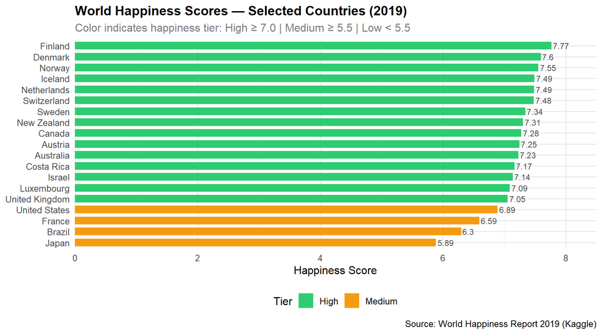

```r
happiness %>%
  filter(rank <= 15 | country %in% c("United States","France","Japan","Brazil")) %>%
  mutate(country = fct_reorder(country, score)) %>%
  ggplot(aes(x = score, y = country, fill = tier)) +
  geom_col(width = 0.7) +
  geom_text(aes(label = round(score, 2)), hjust = -0.1, size = 3.2, color = "grey30") +
  scale_fill_manual(values = c("High" = "#2ecc71", "Medium" = "#f39c12", "Low" = "#e74c3c")) +
  scale_x_continuous(limits = c(0, 8.5), expand = c(0, 0)) +
  labs(
    title    = "World Happiness Scores — Selected Countries (2019)",
    subtitle = "Color indicates happiness tier: High ≥ 7.0 | Medium ≥ 5.5 | Low < 5.5",
    x        = "Happiness Score",
    y        = NULL,
    fill     = "Tier",
    caption  = "Source: World Happiness Report 2019 (Kaggle)"
  ) +
  theme_minimal(base_size = 12) +
  theme(
    plot.title    = element_text(face = "bold", size = 14),
    plot.subtitle = element_text(color = "grey50"),
    legend.position = "bottom"
  )
```

### 6b. Regional Radar-Style Grouped Bar Chart

Using the pivoted long data to compare six happiness factors across regions.

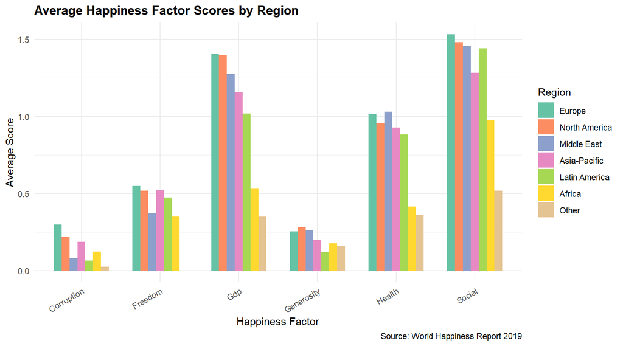

```r
happiness_long %>%
  group_by(region, factor) %>%
  summarise(avg_value = mean(value, na.rm = TRUE), .groups = "drop") %>%
  mutate(
    factor = str_to_title(str_replace(factor, "_", " ")),  # stringr cleanup
    region = fct_reorder(region, avg_value, .fun = mean, .desc = TRUE)
  ) %>%
  ggplot(aes(x = factor, y = avg_value, fill = region)) +
  geom_col(position = "dodge", width = 0.7) +
  scale_fill_brewer(palette = "Set2") +
  labs(
    title   = "Average Happiness Factor Scores by Region",
    x       = "Happiness Factor",
    y       = "Average Score",
    fill    = "Region",
    caption = "Source: World Happiness Report 2019"
  ) +
  theme_minimal(base_size = 11) +
  theme(
    axis.text.x     = element_text(angle = 30, hjust = 1),
    plot.title      = element_text(face = "bold"),
    legend.position = "right"
  )
```

### 6c. GDP vs Happiness Scatter (with `ggplot2` smooth + labels)

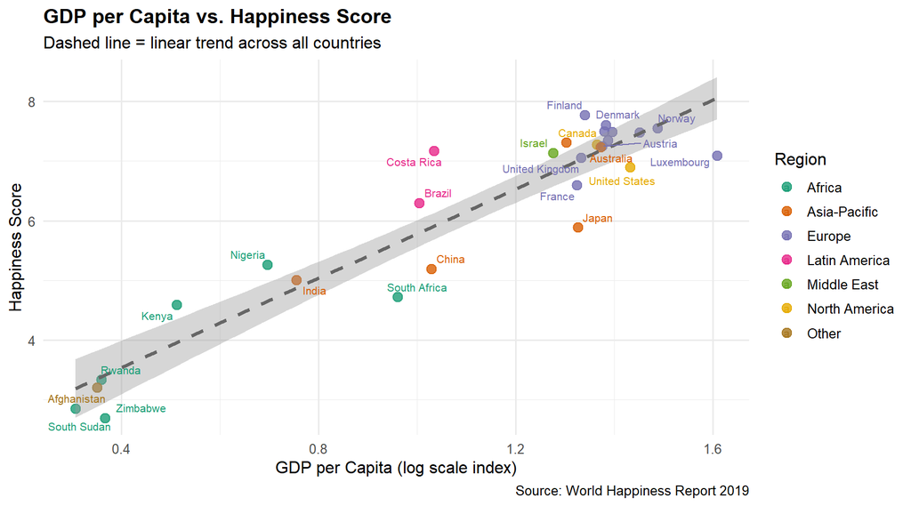

```r
library(ggrepel)  # install if needed: install.packages("ggrepel")

happiness %>%
  ggplot(aes(x = gdp, y = score, color = region, label = country)) +
  geom_point(size = 3, alpha = 0.8) +
  geom_smooth(method = "lm", se = TRUE, color = "grey40", linetype = "dashed",
              aes(group = 1)) +
  ggrepel::geom_text_repel(size = 2.8, max.overlaps = 12) +
  scale_color_brewer(palette = "Dark2") +
  labs(
    title    = "GDP per Capita vs. Happiness Score",
    subtitle = "Dashed line = linear trend across all countries",
    x        = "GDP per Capita (log scale index)",
    y        = "Happiness Score",
    color    = "Region",
    caption  = "Source: World Happiness Report 2019"
  ) +
  theme_minimal(base_size = 12) +
  theme(plot.title = element_text(face = "bold"))
```

## 7. Advanced `dplyr`: Window Functions

`dplyr` supports window functions via `mutate()` — calculations that reference other rows in the same group without collapsing them.

```r
happiness %>%
  group_by(region) %>%
  mutate(
    region_rank     = rank(desc(score)),          # rank within region
    score_vs_avg    = score - mean(score),        # deviation from regional mean
    pct_of_top      = score / max(score) * 100    # % of region's top scorer
  ) %>%
  ungroup() %>%
  arrange(region, region_rank) %>%
  select(country, region, score, region_rank, score_vs_avg, pct_of_top) %>%
  head(12)
```

```
## # A tibble: 12 × 6
##    country      region       score region_rank score_vs_avg pct_of_top
##    <chr>        <chr>        <dbl>       <dbl>        <dbl>      <dbl>
##  1 Nigeria      Africa        5.26           1        1.36       100
##  2 South Africa Africa        4.72           2        0.813       89.7
##  3 Kenya        Africa        4.59           3        0.679       87.1
##  4 Rwanda       Africa        3.33           4       -0.575       63.3
##  5 South Sudan  Africa        2.85           5       -1.06        54.2
##  6 Zimbabwe     Africa        2.69           6       -1.22        51.2
##  7 New Zealand  Asia-Pacific  7.31           1        1.18       100
##  8 Australia    Asia-Pacific  7.23           2        1.10        98.9
##  9 Japan        Asia-Pacific  5.89           3       -0.237       80.6
## 10 China        Asia-Pacific  5.19           4       -0.932       71.0
## 11 India        Asia-Pacific  5.00           5       -1.12        68.5
## 12 Finland      Europe        7.77           1        0.432      100
```

## 8. `tidyr::drop_na()` & Data Quality Check

Real datasets have missing values. `drop_na()` removes rows with `NA` in specified columns — critical before modelling.

```r
cat("Rows before drop_na():", nrow(happiness), "\n")
```

```
## Rows before drop_na(): 28
```

```r
happiness_clean <- happiness %>%
  drop_na(score, gdp, social, health, freedom)

cat("Rows after  drop_na():", nrow(happiness_clean), "\n")
```

```
## Rows after  drop_na(): 28
```

## 9. `stringr` Showcase

`stringr` provides consistent, pipe-friendly string manipulation.

```r
happiness %>%
  mutate(
    # Detect countries containing multi-word names
    multi_word    = str_detect(country, " "),
    # Extract first word of country name
    first_word    = str_extract(country, "^\\w+"),
    # Count characters in country name
    name_length   = str_length(country),
    # Uppercase the tier label
    tier_upper    = str_to_upper(as.character(tier))
  ) %>%
  select(country, first_word, name_length, multi_word, tier_upper) %>%
  arrange(desc(name_length))
```

```
## # A tibble: 28 × 5
##    country        first_word  name_length multi_word tier_upper
##    <chr>          <chr>             <int> <lgl>      <chr>
##  1 United Kingdom United               14 TRUE       HIGH
##  2 United States  United               13 TRUE       MEDIUM
##  3 South Africa   South                12 TRUE       LOW
##  4 Netherlands    Netherlands          11 FALSE      HIGH
##  5 Switzerland    Switzerland          11 FALSE      HIGH
##  6 New Zealand    New                  11 TRUE       HIGH
##  7 Afghanistan    Afghanistan          11 FALSE      LOW
##  8 South Sudan    South                11 TRUE       LOW
##  9 Costa Rica     Costa                10 TRUE       HIGH
## 10 Luxembourg     Luxembourg           10 FALSE      HIGH
## # ℹ 18 more rows
```

## 10. Key Takeaways

This vignette demonstrated:

The **pipe operator (`%>%`)** ties these packages together into readable, left-to-right data transformation chains — the defining feature of the TidyVerse philosophy.